# Exploratory Data Analysis

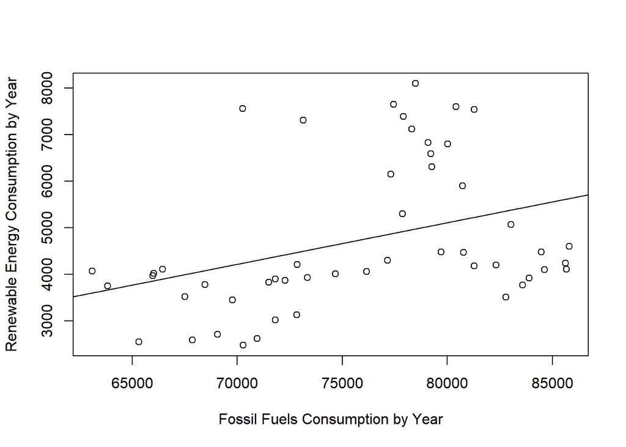

```r
assocreg = lm(`Renewable Energy Consumption by Year` ~ `Fossil Fuels Consumption by Year`, data = Q1_year)
plot(`Renewable Energy Consumption by Year` ~ `Fossil Fuels Consumption by Year`, data = Q1_year)
abline(assocreg)
```

```r
#combining linear regressions into a table

data.frame(Model = c("Renewable Energy Consumption and Year", "Fossil Fuels Consumption and Year", "Renewable Energy and Fossil Fuels Consumption"), Coefficient = c(summary(renewreg)$coefficients[2,1], summary(nonrenewreg)$coefficients[2,1], summary(assocreg)$coefficients[2,1]), t_value = c(summary(renewreg)$coefficients[2,3], summary(nonrenewreg)$coefficients[2,3], summary(assocreg)$coefficients[2,3]), p_value = c(summary(renewreg)$coefficients[2,4],  summary(nonrenewreg)$coefficients[2,4], summary(assocreg)$coefficients[2,4])) %>%
  kbl(caption = "Summary Statistics for Energy Consumption Linear Regression Models", "html") %>%
  kable_material_dark()
```

Summary Statistics for Energy Consumption Linear Regression Models

| Model | Coefficient | t_value | p_value |
| --- | --- | --- | --- |
| Renewable Energy Consumption and Year | 97.7148951 | 15.761226 | 0.0000000 |
| Fossil Fuels Consumption and Year | 286.6056633 | 6.150025 | 0.0000001 |
| Renewable Energy and Fossil Fuels Consumption | 0.0891322 | 2.718350 | 0.0090468 |

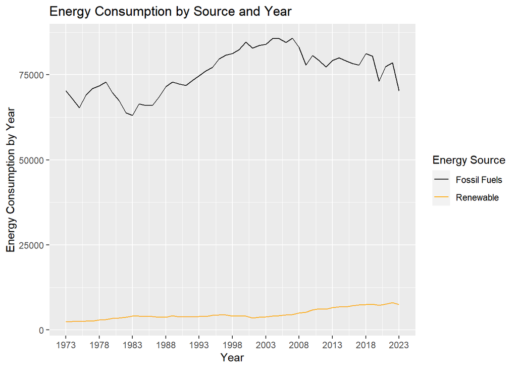

```r
#overall graph depicting Energy Consumption by Year

colors1 = c("Renewable" = "orange", "Fossil Fuels" = "black")

Q1_year %>%
  ggplot(aes(x=Year)) +
  geom_line(aes(y=`Renewable Energy Consumption by Year`, color = "Renewable")) +
  geom_line(aes(y=`Fossil Fuels Consumption by Year`, color = "Fossil Fuels")) +
  scale_x_continuous(breaks = seq(min(Q1_EE$Year), max(Q1_EE$Year), by = 5)) +
  scale_color_manual(name = "Energy Source", values = colors1) +
  ylab("Energy Consumption by Year") +
  labs(title = "Energy Consumption by Source and Year")
```

### Q2: Is there a pattern between the change in electrical system energy losses and the appearance of renewable energy forms? Are nonrenewable or renewable energy sources better at converting energy losses and providing more electricity?

Note: the stepwise model used is extremely basic and only used to create a multiple regression describing electrical losses. Further analyses would cross validate and test the model at length, as it has confusing and potentially contradictory output.

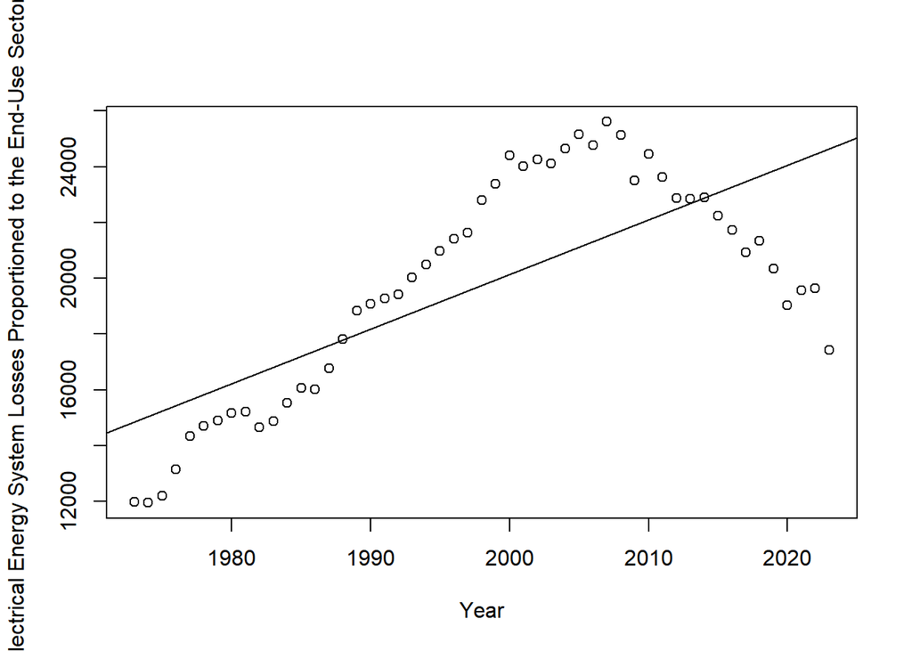

```r
#selecting desired data from Energy and summarizing by Year

Q2_year <- Energy %>%
  select("Year", "Total Fossil Fuels Production", "Nuclear Electric Power Production", "Total Renewable Energy Production", "Total Fossil Fuels Consumption", "Nuclear Electric Power Consumption", "Total Renewable Energy Consumption", "Total Electrical Energy System Losses Proportioned to the End-Use Sectors") %>%
  mutate(Year = as.numeric(Year)) %>%
  group_by(Year) %>%
  summarize(`Renewable Energy Consumption by Year` = sum(`Total Renewable Energy Consumption`), `Fossil Fuels Consumption by Year` = sum(`Total Fossil Fuels Consumption`), `Nuclear Electric Power Consumption by Year` = sum(`Nuclear Electric Power Consumption`), `Renewable Energy Production by Year` = sum(`Total Renewable Energy Production`), `Fossil Fuels Production by Year` = sum(`Total Fossil Fuels Production`), `Nuclear Electric Power Production by Year` = sum(`Nuclear Electric Power Production`), `Total Electrical Energy System Losses Proportioned to the End-Use Sectors by Year` = sum(`Total Electrical Energy System Losses Proportioned to the End-Use Sectors`)) %>% ungroup()

#linear regressions

mod1 = lm(`Total Electrical Energy System Losses Proportioned to the End-Use Sectors by Year` ~ Year, data = Q2_year)
plot(`Total Electrical Energy System Losses Proportioned to the End-Use Sectors by Year` ~ Year, data = Q2_year)
abline(mod1)
```

```r
mod2c = lm(`Total Electrical Energy System Losses Proportioned to the End-Use Sectors by Year` ~ `Renewable Energy Consumption by Year`, data = Q2_year)

mod3c = lm(`Total Electrical Energy System Losses Proportioned to the End-Use Sectors by Year` ~ `Fossil Fuels Consumption by Year`, data = Q2_year)

mod4c = lm(`Total Electrical Energy System Losses Proportioned to the End-Use Sectors by Year` ~ `Nuclear Electric Power Consumption by Year`, data = Q2_year)

mod2p = lm(`Total Electrical Energy System Losses Proportioned to the End-Use Sectors by Year` ~ `Renewable Energy Production by Year`, data = Q2_year)

mod3p = lm(`Total Electrical Energy System Losses Proportioned to the End-Use Sectors by Year` ~ `Fossil Fuels Production by Year`, data = Q2_year)

mod4p = lm(`Total Electrical Energy System Losses Proportioned to the End-Use Sectors by Year` ~ `Nuclear Electric Power Production by Year`, data = Q2_year)


#combining linear regressions into a table

data.frame(Model = c("Electrical Energy System Losses and Year", "Electrical Losses and Renewable Energy Consumption", "Electrical Losses and Fossil Fuels Consumption", "Electrical Losses and Nuclear Electric Power Consumption"), Coefficient = c(summary(mod1)$coefficients[2,1], summary(mod2c)$coefficients[2,1], summary(mod3c)$coefficients[2,1], summary(mod4c)$coefficients[2,1]), t_value = c(summary(mod1)$coefficients[2,3], summary(mod2c)$coefficients[2,3], summary(mod3c)$coefficients[2,3], summary(mod4c)$coefficients[2,3]), p_value = c(summary(mod1)$coefficients[2,4],  summary(mod2c)$coefficients[2,4], summary(mod3c)$coefficients[2,4], summary(mod4c)$coefficients[2,4])) %>%
  kbl(caption = "Summary Statistics for Energy Consumption and Electrical Loss Linear Regression Models", "html") %>%
  kable_material_dark()
```

Summary Statistics for Energy Consumption and Electrical Loss Linear Regression Models

| Model | Coefficient | t_value | p_value |
| --- | --- | --- | --- |
| Electrical Energy System Losses and Year | 195.8683300 | 7.389785 | 0.0000000 |
| Electrical Losses and Renewable Energy Consumption | 1.0982217 | 3.383858 | 0.0014139 |
| Electrical Losses and Fossil Fuels Consumption | 0.5680063 | 15.791995 | 0.0000000 |
| Electrical Losses and Nuclear Electric Power Consumption | 1.5564553 | 16.807833 | 0.0000000 |

```r
data.frame(Model = c("Electrical Energy System Losses and Year", "Electrical Losses and Renewable Energy Production", "Electrical Losses and Fossil Fuels Production", "Electrical Losses and Nuclear Electric Power Production"), Coefficient = c(summary(mod1)$coefficients[2,1], summary(mod2p)$coefficients[2,1], summary(mod3p)$coefficients[2,1], summary(mod4p)$coefficients[2,1]), t_value = c(summary(mod1)$coefficients[2,3], summary(mod2p)$coefficients[2,3], summary(mod3p)$coefficients[2,3], summary(mod4p)$coefficients[2,3]), p_value = c(summary(mod1)$coefficients[2,4],  summary(mod2p)$coefficients[2,4], summary(mod3p)$coefficients[2,4], summary(mod4p)$coefficients[2,4])) %>%
  kbl(caption = "Summary Statistics for Energy Production and Electrical Loss Linear Regression Models", "html") %>%
  kable_material_dark()
```

Summary Statistics for Energy Production and Electrical Loss Linear Regression Models

| Model | Coefficient | t_value | p_value |
| --- | --- | --- | --- |
| Electrical Energy System Losses and Year | 195.8683300 | 7.389785 | 0.0000000 |
| Electrical Losses and Renewable Energy Production | 1.0370736 | 3.276883 | 0.0019328 |
| Electrical Losses and Fossil Fuels Production | 0.0556088 | 0.730953 | 0.4682889 |
| Electrical Losses and Nuclear Electric Power Production | 1.5564553 | 16.807833 | 0.0000000 |

```r
#Basic Model Analysis

FullModel = lm(`Total Electrical Energy System Losses Proportioned to the End-Use Sectors by Year`~., data = Q2_year)

MSE = (summary(FullModel)$sigma)^2

NoModel = lm(`Total Electrical Energy System Losses Proportioned to the End-Use Sectors by Year`~1, data = Q2_year)

summary(step(NoModel, scope = list(upper=FullModel), scale = MSE))
```

```
## Start:  AIC=2966.66
## `Total Electrical Energy System Losses Proportioned to the End-Use Sectors by Year` ~
##     1
##
##                                                Df Sum of Sq       RSS      Cp
## + `Nuclear Electric Power Consumption by Year`  1 685424962 118886502  398.75
## + `Nuclear Electric Power Production by Year`   1 685424962 118886502  398.75
## + `Fossil Fuels Consumption by Year`            1 672230478 132080986  448.22
## + Year                                          1 423926650 380384814 1379.20
## + `Renewable Energy Consumption by Year`        1 152352145 651959319 2397.44
## + `Renewable Energy Production by Year`         1 144575862 659735602 2426.59
## + `Fossil Fuels Production by Year`             1   8675553 795635911 2936.13
## <none>                                                      804311464 2966.66
##
## Step:  AIC=398.75
## `Total Electrical Energy System Losses Proportioned to the End-Use Sectors by Year` ~
##     `Nuclear Electric Power Consumption by Year`
##
##                                                Df Sum of Sq       RSS       Cp
## + `Fossil Fuels Production by Year`             1  84770565  34115937   82.913
## + `Renewable Energy Production by Year`         1  78239179  40647322  107.402
## + `Renewable Energy Consumption by Year`        1  76969534  41916967  112.162
## + Year                                          1  61542649  57343853  170.003
## + `Fossil Fuels Consumption by Year`            1  60291359  58595142  174.695
## <none>                                                      118886502  398.750
## - `Nuclear Electric Power Consumption by Year`  1 685424962 804311464 2966.661
##
## Step:  AIC=82.91
## `Total Electrical Energy System Losses Proportioned to the End-Use Sectors by Year` ~
##     `Nuclear Electric Power Consumption by Year` + `Fossil Fuels Production by Year`
##
##                                                Df Sum of Sq       RSS        Cp
## + `Fossil Fuels Consumption by Year`            1  20322831  13793106    8.7155
## + `Renewable Energy Production by Year`         1   1936077  32179860   77.6542
## + `Renewable Energy Consumption by Year`        1   1791931  32324006   78.1947
## <none>                                                       34115937   82.9133
## + Year                                          1    195373  33920563   84.1807
## - `Fossil Fuels Production by Year`             1  84770565 118886502  398.7495
## - `Nuclear Electric Power Consumption by Year`  1 761519975 795635911 2936.1333
##
```

[output cut: 27 more lines]

```
##
## Step:  AIC=5.28
## `Total Electrical Energy System Losses Proportioned to the End-Use Sectors by Year` ~
##     `Nuclear Electric Power Consumption by Year` + `Fossil Fuels Production by Year` +
##         `Fossil Fuels Consumption by Year` + `Renewable Energy Consumption by Year` +
##         `Renewable Energy Production by Year`
##
##                                                Df Sum of Sq      RSS       Cp
## <none>                                                      11810758   5.2829
## + Year                                          1     75453 11735305   7.0000
## - `Renewable Energy Production by Year`         1   1311525 13122283   8.2003
## - `Renewable Energy Consumption by Year`        1   1415152 13225910   8.5888
## - `Fossil Fuels Production by Year`             1   6856024 18666782  28.9887
## - `Fossil Fuels Consumption by Year`            1  19334210 31144968  75.7740
## - `Nuclear Electric Power Consumption by Year`  1  42053887 53864645 160.9585
```

```
##
## Call:
## lm(formula = `Total Electrical Energy System Losses Proportioned to the End-Use Sectors by Year` ~
##     `Nuclear Electric Power Consumption by Year` + `Fossil Fuels Production by Year` +
##         `Fossil Fuels Consumption by Year` + `Renewable Energy Consumption by Year` +
##         `Renewable Energy Production by Year`, data = Q2_year)
##
## Residuals:
##      Min       1Q   Median       3Q      Max
## -1000.00  -327.54   -36.34   420.03   965.72
##
## Coefficients:
##                                                Estimate Std. Error t value
## (Intercept)                                  4235.93710 1967.24025   2.153
## `Nuclear Electric Power Consumption by Year`    1.20857    0.09548  12.658
## `Fossil Fuels Production by Year`              -0.14788    0.02893  -5.111
## `Fossil Fuels Consumption by Year`              0.20649    0.02406   8.583
## `Renewable Energy Consumption by Year`          6.42759    2.76808   2.322
## `Renewable Energy Production by Year`          -6.11665    2.73626  -2.235
##                                              Pr(>|t|)
## (Intercept)                                    0.0367 *
## `Nuclear Electric Power Consumption by Year`  < 2e-16 ***
## `Fossil Fuels Production by Year`            6.35e-06 ***
## `Fossil Fuels Consumption by Year`           4.97e-11 ***
## `Renewable Energy Consumption by Year`         0.0248 *
## `Renewable Energy Production by Year`          0.0304 *
## ---
## Signif. codes:  0 '***' 0.001 '**' 0.01 '*' 0.05 '.' 0.1 ' ' 1
##
## Residual standard error: 512.3 on 45 degrees of freedom
## Multiple R-squared:  0.9853, Adjusted R-squared:  0.9837
## F-statistic: 603.9 on 5 and 45 DF,  p-value: < 2.2e-16
```

```r
#Best Model with Table

BestModel = lm(formula = `Total Electrical Energy System Losses Proportioned to the End-Use Sectors by Year` ~
    `Nuclear Electric Power Consumption by Year` + `Fossil Fuels Production by Year` +
        `Fossil Fuels Consumption by Year` + `Renewable Energy Consumption by Year` +
        `Renewable Energy Production by Year`, data = Q2_year)

data.frame(Model = c("Nuclear Electric Power Consumption", "Fossil Fuels Production", "Fossil Fuels Consumption", "Renewable Energy Consumption", "Renewable Energy Production"), Coefficient = c(summary(BestModel)$coefficients[2,1], summary(BestModel)$coefficients[3,1], summary(BestModel)$coefficients[4,1], summary(BestModel)$coefficients[5,1], summary(BestModel)$coefficients[6,1]), t_value = c(summary(BestModel)$coefficients[2,3], summary(BestModel)$coefficients[3,3], summary(BestModel)$coefficients[4,3], summary(BestModel)$coefficients[5,3], summary(BestModel)$coefficients[6,3]), p_value = c(summary(BestModel)$coefficients[2,4],  summary(BestModel)$coefficients[3,4], summary(BestModel)$coefficients[4,4], summary(BestModel)$coefficients[5,4], summary(BestModel)$coefficients[6,4])) %>%
  kbl(caption = "Summary Statistics for Electrical Loss Linear Regression Model with Highest Explanatory Power", "html") %>%
  kable_material_dark()
```

Summary Statistics for Electrical Loss Linear Regression Model with Highest Explanatory Power

| Model | Coefficient | t_value | p_value |
| --- | --- | --- | --- |
| Nuclear Electric Power Consumption | 1.2085672 | 12.658156 | 0.0000000 |
| Fossil Fuels Production | -0.1478755 | -5.110972 | 0.0000064 |
| Fossil Fuels Consumption | 0.2064895 | 8.582831 | 0.0000000 |
| Renewable Energy Consumption | 6.4275921 | 2.322036 | 0.0248145 |
| Renewable Energy Production | -6.1166482 | -2.235402 | 0.0303979 |

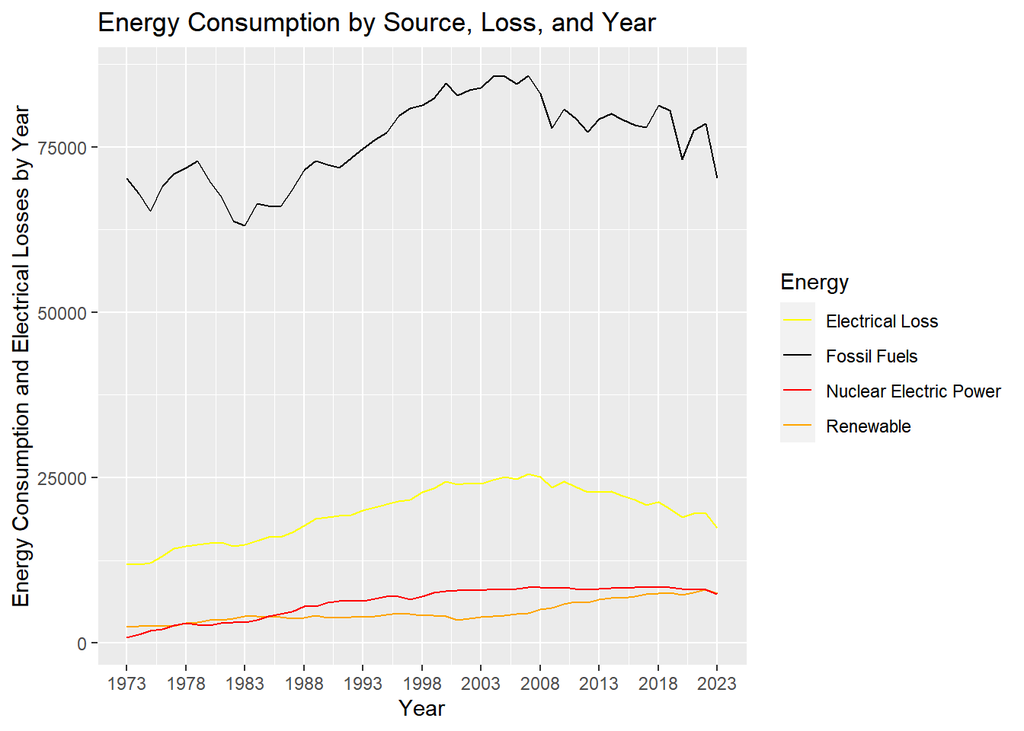

```r
#overall graphs depicting all trends

colors2 = c("Renewable" = "orange", "Fossil Fuels" = "black", "Nuclear Electric Power" = "red", "Electrical Loss" = "yellow")

Q2_year %>%
  ggplot(aes(x=Year)) +
  geom_line(aes(y=`Renewable Energy Consumption by Year`, color = "Renewable")) +
  geom_line(aes(y=`Fossil Fuels Consumption by Year`, color = "Fossil Fuels")) +
  geom_line(aes(y = `Nuclear Electric Power Consumption by Year`, color = "Nuclear Electric Power")) +
  geom_line(aes(y = `Total Electrical Energy System Losses Proportioned to the End-Use Sectors by Year`, color = "Electrical Loss")) +
  scale_x_continuous(breaks = seq(min(Q2_year$Year), max(Q2_year$Year), by = 5)) +
  scale_color_manual(name = "Energy", values = colors2) +
  ylab("Energy Consumption and Electrical Losses by Year") +
  labs(title = "Energy Consumption by Source, Loss, and Year")
```

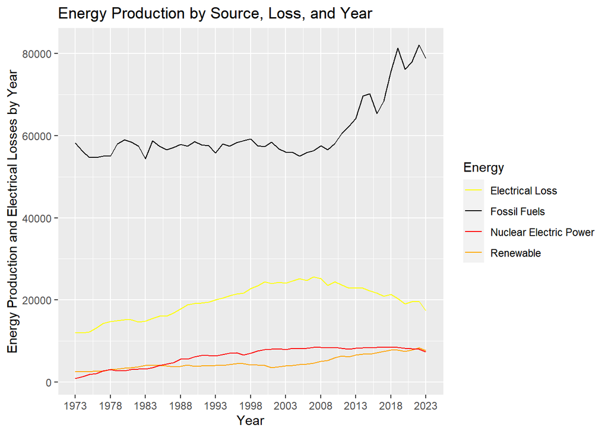

```r
Q2_year %>%
  ggplot(aes(x=Year)) +
  geom_line(aes(y=`Renewable Energy Production by Year`, color = "Renewable")) +
  geom_line(aes(y=`Fossil Fuels Production by Year`, color = "Fossil Fuels")) +
  geom_line(aes(y = `Nuclear Electric Power Production by Year`, color = "Nuclear Electric Power")) +
  geom_line(aes(y = `Total Electrical Energy System Losses Proportioned to the End-Use Sectors by Year`, color = "Electrical Loss")) +
  scale_x_continuous(breaks = seq(min(Q2_year$Year), max(Q2_year$Year), by = 5)) +
  scale_color_manual(name = "Energy", values = colors2) +
  ylab("Energy Production and Electrical Losses by Year") +
  labs(title = "Energy Production by Source, Loss, and Year")
```